# Statistical analyses

## Best-models (most parsimonious)

Check results of the best-fit models

1. Cluster dataset

```
Computing bootstrap confidence intervals ...

14 message(s): boundary (singular) fit: see ?isSingular
```

Best-fit model Ho

[output not shown]

```
Computing bootstrap confidence intervals ...

5 message(s): boundary (singular) fit: see ?isSingular
```

Best-fit model He

| term | estimate | conf.low | conf.high | p.value | df |
| --- | --- | --- | --- | --- | --- |
| (Intercept) | 0.630 | 0.594 | 0.666 | 0.0000000 | 10.68532 |
| GL | 0.054 | 0.023 | 0.085 | 0.0020856 | 16.29614 |
| sample.size_log | 0.022 | 0.007 | 0.036 | 0.0033883 | 182.94851 |
| sd__(Intercept) | 0.051 | 0.014 | 0.083 | NA | NA |
| sd__Observation | 0.087 | 0.077 | 0.096 | NA | NA |

```
Computing bootstrap confidence intervals ...

5 message(s): boundary (singular) fit: see ?isSingular
```

Best-fit model AR

| term | estimate | conf.low | conf.high | p.value | df |
| --- | --- | --- | --- | --- | --- |
| (Intercept) | 0.673 | 0.625 | 0.720 | 0.0000000 | 10.94193 |
| DP_log | 0.028 | 0.008 | 0.048 | 0.0058448 | 182.49184 |
| GL | 0.057 | 0.015 | 0.100 | 0.0118448 | 15.51133 |
| sample.size_log | 0.086 | 0.067 | 0.105 | 0.0000000 | 184.92601 |
| sd__(Intercept) | 0.066 | 0.016 | 0.108 | NA | NA |
| sd__Observation | 0.120 | 0.108 | 0.134 | NA | NA |

- Country data set

```
Computing bootstrap confidence intervals ...
```

Best-fit model Ho

| term | estimate | conf.low | conf.high | p.value | df |
| --- | --- | --- | --- | --- | --- |
| (Intercept) | 0.593 | 0.548 | 0.638 | 0.0000000 | 7.474694 |
| DP_log | 0.039 | 0.021 | 0.057 | 0.0000411 | 177.070144 |
| GL | 0.054 | 0.019 | 0.089 | 0.0065637 | 10.008339 |
| BS_log | 0.026 | -0.012 | 0.064 | 0.1625698 | 10.346929 |

```
Computing bootstrap confidence intervals ...
```

Best-fit model He

| term | estimate | conf.low | conf.high | p.value | df |
| --- | --- | --- | --- | --- | --- |
| (Intercept) | 0.649 | 0.606 | 0.693 | 0.0000000 | 11.13731 |
| DP_log | 0.021 | 0.002 | 0.040 | 0.0295174 | 201.47148 |
| GL | 0.051 | 0.014 | 0.088 | 0.0101549 | 13.52285 |
| sample.size_log | 0.013 | 0.005 | 0.021 | 0.0020258 | 389.51452 |
| sd__(Intercept) | 0.074 | 0.044 | 0.106 | NA | NA |
| sd__Observation | 0.076 | 0.070 | 0.081 | NA | NA |

```
Computing bootstrap confidence intervals ...

1 message(s): boundary (singular) fit: see ?isSingular
```

Best-fit model AR

| term | estimate | conf.low | conf.high | p.value | df |
| --- | --- | --- | --- | --- | --- |
| (Intercept) | 0.689 | 0.643 | 0.735 | 0.0000000 | 12.15707 |
| DP_log | 0.053 | 0.031 | 0.075 | 0.0000065 | 125.38443 |
| GL | 0.057 | 0.015 | 0.098 | 0.0111012 | 13.92459 |
| sample.size_log | 0.075 | 0.063 | 0.086 | 0.0000000 | 379.31306 |
| sd__(Intercept) | 0.075 | 0.041 | 0.112 | NA | NA |
| sd__Observation | 0.109 | 0.102 | 0.116 | NA | NA |

Compare the covariates estimates

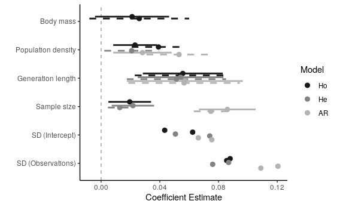

#### Model validation

check the assumption of equal variances (homoscedasticity)

```r
## Best-fit models
plot(best_Ho)
plot(best_He)
plot(best_mna)
```

[output not shown]

2. Country final models

```r
df <- df_Ho.c[!df_Ho.c$ho_out & !df_Ho.c$dp_out,]
df$GL  <- df$GenerationLength_d
```

scale all covariates to have mean = 0 and standard deviation = 1

```r
df <- df %>% mutate_at(c("DP_log","GL","BS_log","sample.size_log"), ~(scale(.) %>% as.vector))
for (i in 1:4) {
  var <- c("DP_log","GL","BS_log","sample.size_log")
  print(fixef(lmer(paste("ho ~", var[i], "+ (1|sp)"), data=df ))[2])

}
```

- Ho

```r
null_Ho <- lmer(ho ~ 1 + (1|sp), data = df, REML = F)
full_Ho <- update(null_Ho, . ~ . + GL)
full_Ho_1 <- update(full_Ho, . ~ . + DP_log)
full_Ho_2 <- update(full_Ho_1, . ~ . + BS_log)
full_Ho_3 <- update(full_Ho_2, . ~ . + sample.size_log)

compare_performance(null_Ho, full_Ho, full_Ho_1, full_Ho_2, full_Ho_3, rank = TRUE)

options(na.action = na.fail)
dr_Ho <- dredge(full_Ho_3, fixed=~(1|sp),
                rank = "AIC", extra = list("R2M" = function(x) {r.squaredGLMM(x)[1]}, "R2C" = function(x) r.squaredGLMM(x)[2], "var. sp" = function(x) as.numeric(insight::get_variance_random(x))))


# Set as data.frame

dr_Ho.df.c <- dredge2df(dr=dr_Ho)
```

##### Ho

##### He

[figure not shown]

##### AR

[figure not shown]

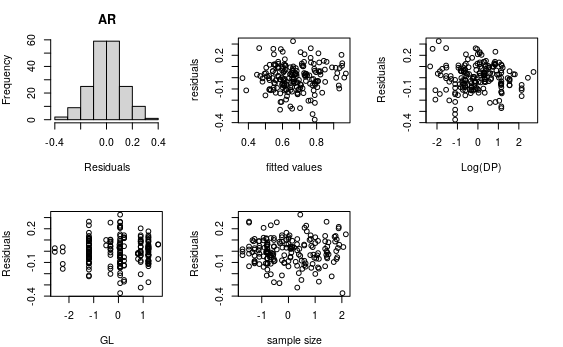

## PD in cluster vs country

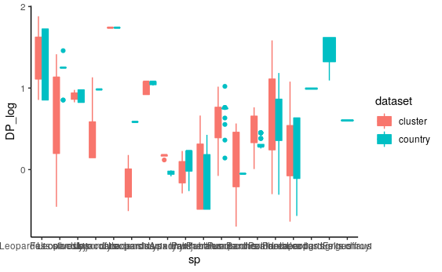

```r
tdy <- He.lmer@frame %>% mutate(dataset="cluster")

tdy.c <- He.c.lmer@frame %>% mutate(dataset="country")

tdy.com <- rbind(tdy, tdy.c)
tdy.com$dataset <- as.factor(tdy.com$dataset)

ggplot(data=tdy.com, aes(x=sp, y=DP_log, color=dataset, fill=dataset)) + geom_boxplot()
```

```r
table(tdy.com$sp, tdy.com$dataset)
```

```
                      cluster country
  Leopardus colocolo        2       6
  Felis silvestris          3      10
  Leopardus jacobita        2       4
  Lynx rufus                4      59
  Lynx canadensis           1      44
  Lynx pardinus             2       2
  Leopardus pardalis       11      10
  Lynx lynx                 5       3
  Acinonyx jubatus          2      11
  Panthera uncia           13      11
  Panthera pardus          18      20
  Puma concolor            14      73
  Panthera onca            39      44
  Panthera leo             41      67
  Panthera tigris          29      33
  Leopardus tigrinus        0       1
  Leopardus geoffroyi       0       4
  Felis chaus               0       1
```

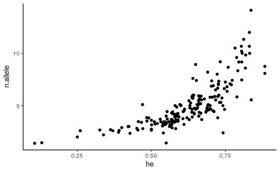

```r
ggplot(data=gen_clus, aes(x=he, y=n.allele)) + geom_point()
```

## fitted values by sp

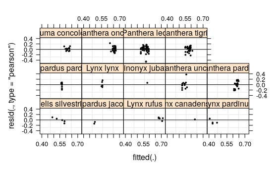

```r
plot(Ho.lmer.out, form = resid(., type = "pearson") ~ fitted(.) | sp, abline = 0,
     cex = .5, pch = 20, col = "black")
```

```r
#include outliers
df_Ho.c$GL <- df_Ho.c$GenerationLength_d
best_Ho.c1 <- update(best_Ho.c, data=df_Ho.c)
summary(best_Ho.c1)
##
```

- He

```r
for (i in 1:4) {
  var <- c("DP_log","GL","BS_log","sample.size_log")
  print(fixef(lmer(paste("he ~", var[i], "+ (1|sp)"), data=df ))[2])

}
```

```r
library(nlme)
m4.lme = lme(ho ~ DP_log, random = ~1|sp, data = df_Ho, method = "ML")

m5.lme <- update(m4.lme, weights = varIdent(form = ~ 1 | sp), control = lmeControl(msMaxIter = 1000, msMaxEval = 1000))
# compare models
anova(m5.lme, m4.lme)
```

|  | Model | df | AIC | BIC | logLik | Test | L.Ratio | p-value |
| --- | --- | --- | --- | --- | --- | --- | --- | --- |
| m5.lme | 1 | 17 | -287.4648 | -231.5643 | 160.7324 |  |  |  |
| m4.lme | 2 | 4 | -289.0684 | -275.9154 | 148.5342 | 1 vs 2 | 24.3964 | 0.0277 |

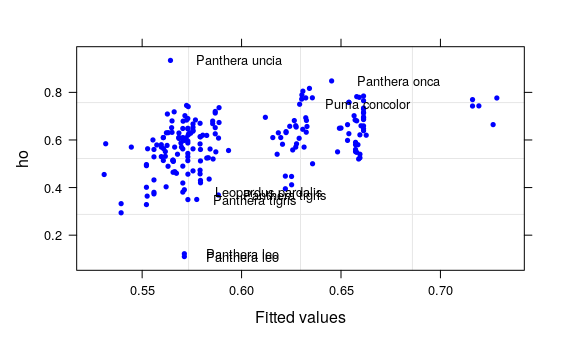

```r
# observed responses versus the within-group fitted values
plot(m5.lme, ho ~ fitted(.), id = 0.05, adj = -0.3,
     , cex = .8, pch = 20, col = "blue")
```

## Conduct leave-one-out cross validation I’m not entirely sure about this approach

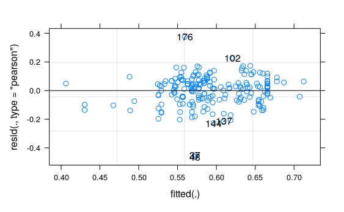

```r
plot(Ho.lmer.out, id = 0.05, idLabels = ~.obs)
```

```r
df_Ho[c(179,104,139,146,37,48),]
```

[output not shown]

- AR

```r
for (i in 1:4) {
  var <- c("DP_log","GL","BS_log","sample.size_log")
  print(fixef(lmer(paste("log10(n.allele) ~", var[i], "+ (1|sp)"), data=df))[2])

}
```

## Manually

Using all data (including outliers) The list’s name indicate the species data that were left out

### Cluster dataset

*Ho*

```r
sp_i <- unique(df_Ho$sp)
res_sp <- list()

for (i in sp_i) {
  res_sp[[i]] <- update(Ho.lmer.out, data=df_Ho[-which(df_Ho$sp == i),])
}

lapply(res_sp, summary)
```

```
$`Acinonyx jubatus`
Linear mixed model fit by maximum likelihood . t-tests use
  Satterthwaite's method [lmerModLmerTest]
Formula: ho ~ DP_log + (1 | sp)
   Data: df_Ho[-which(df_Ho$sp == i), ]

     AIC      BIC   logLik deviance df.resid
  -287.4   -274.3    147.7   -295.4      193

Scaled residuals:
    Min      1Q  Median      3Q     Max
-4.2918 -0.5622  0.1684  0.6154  3.4789

Random effects:
 Groups   Name        Variance Std.Dev.
 sp       (Intercept) 0.00572  0.07563
 Residual             0.01161  0.10774
Number of obs: 197, groups:  sp, 13

Fixed effects:
             Estimate Std. Error        df t value Pr(>|t|)
(Intercept)   0.55779    0.02509  10.45702  22.235 3.82e-10 ***
DP_log        0.03623    0.01629 196.65399   2.224   0.0273 *
---
Signif. codes:  0 ‘***’ 0.001 ‘**’ 0.01 ‘*’ 0.05 ‘.’ 0.1 ‘ ’ 1

Correlation of Fixed Effects:
       (Intr)
DP_log -0.305

$`Felis silvestris`
Linear mixed model fit by maximum likelihood . t-tests use
  Satterthwaite's method [lmerModLmerTest]
Formula: ho ~ DP_log + (1 | sp)
   Data: df_Ho[-which(df_Ho$sp == i), ]

     AIC      BIC   logLik deviance df.resid
  -280.3   -267.3    144.2   -288.3      189

Scaled residuals:
```

[output cut: 364 more lines]

```
 Groups   Name        Variance Std.Dev.
 sp       (Intercept) 0.005786 0.07606
 Residual             0.012211 0.11050
Number of obs: 184, groups:  sp, 13

Fixed effects:
             Estimate Std. Error        df t value Pr(>|t|)
(Intercept)   0.55547    0.02610  10.56680  21.285  5.1e-10 ***
DP_log        0.03702    0.01710 183.80632   2.165   0.0317 *
---
Signif. codes:  0 ‘***’ 0.001 ‘**’ 0.01 ‘*’ 0.05 ‘.’ 0.1 ‘ ’ 1

Correlation of Fixed Effects:
       (Intr)
DP_log -0.310
```

*He*

```r
sp_i <- unique(df_He$sp)
res_sp <- list()

for (i in sp_i) {
  res_sp[[i]] <- update(He.lmer.out, data=df_He[-which(df_He$sp == i),])
}
lapply(res_sp, summary)
```

```
$`Acinonyx jubatus`
Linear mixed model fit by maximum likelihood . t-tests use
  Satterthwaite's method [lmerModLmerTest]
Formula: he ~ DP_log + (1 | sp)
   Data: df_He[-which(df_He$sp == i), ]

     AIC      BIC   logLik deviance df.resid
  -270.0   -256.8    139.0   -278.0      195

Scaled residuals:
    Min      1Q  Median      3Q     Max
-4.1507 -0.4297  0.0437  0.6439  1.9598

Random effects:
 Groups   Name        Variance Std.Dev.
 sp       (Intercept) 0.004013 0.06335
 Residual             0.013161 0.11472
Number of obs: 199, groups:  sp, 14

Fixed effects:
             Estimate Std. Error        df t value Pr(>|t|)
(Intercept)   0.61339    0.02242  11.25275  27.363 1.19e-11 ***
DP_log        0.01670    0.01752 192.83446   0.953    0.342
---
Signif. codes:  0 ‘***’ 0.001 ‘**’ 0.01 ‘*’ 0.05 ‘.’ 0.1 ‘ ’ 1

Correlation of Fixed Effects:
       (Intr)
DP_log -0.371

$`Felis silvestris`
Linear mixed model fit by maximum likelihood . t-tests use
  Satterthwaite's method [lmerModLmerTest]
Formula: he ~ DP_log + (1 | sp)
   Data: df_He[-which(df_He$sp == i), ]

     AIC      BIC   logLik deviance df.resid
  -266.2   -253.0    137.1   -274.2      192

Scaled residuals:
```

[output cut: 394 more lines]

```
 Groups   Name        Variance Std.Dev.
 sp       (Intercept) 0.004072 0.06381
 Residual             0.013714 0.11711
Number of obs: 187, groups:  sp, 14

Fixed effects:
             Estimate Std. Error        df t value Pr(>|t|)
(Intercept)   0.60792    0.02336  12.41175  26.024 3.32e-12 ***
DP_log        0.02064    0.01834 182.25211   1.125    0.262
---
Signif. codes:  0 ‘***’ 0.001 ‘**’ 0.01 ‘*’ 0.05 ‘.’ 0.1 ‘ ’ 1

Correlation of Fixed Effects:
       (Intr)
DP_log -0.385
```

*Allelic richness*

```r
sp_i <- unique(df_mna$sp)
res_sp <- list()

for (i in sp_i) {
  res_sp[[i]] <- update(mna.lmer.out, data=df_mna[-which(df_mna$sp == i),])
}
lapply(res_sp, summary)
```

```
$`Acinonyx jubatus`
Linear mixed model fit by maximum likelihood . t-tests use
  Satterthwaite's method [lmerModLmerTest]
Formula: n.allele_log ~ DP_log + (1 | sp)
   Data: df_mna[-which(df_mna$sp == i), ]

     AIC      BIC   logLik deviance df.resid
  -142.8   -129.6     75.4   -150.8      195

Scaled residuals:
    Min      1Q  Median      3Q     Max
-3.1936 -0.5868 -0.0072  0.6352  2.4802

Random effects:
 Groups   Name        Variance Std.Dev.
 sp       (Intercept) 0.01127  0.1062
 Residual             0.02442  0.1563
Number of obs: 199, groups:  sp, 14

Fixed effects:
             Estimate Std. Error        df t value Pr(>|t|)
(Intercept)   0.63856    0.03524  13.74703  18.119 5.47e-11 ***
DP_log        0.05784    0.02362 198.98439   2.448   0.0152 *
---
Signif. codes:  0 ‘***’ 0.001 ‘**’ 0.01 ‘*’ 0.05 ‘.’ 0.1 ‘ ’ 1

Correlation of Fixed Effects:
       (Intr)
DP_log -0.350

$`Felis silvestris`
Linear mixed model fit by maximum likelihood . t-tests use
  Satterthwaite's method [lmerModLmerTest]
Formula: n.allele_log ~ DP_log + (1 | sp)
   Data: df_mna[-which(df_mna$sp == i), ]

     AIC      BIC   logLik deviance df.resid
  -143.8   -130.7     75.9   -151.8      192

Scaled residuals:
```

[output cut: 394 more lines]

```
 Groups   Name        Variance Std.Dev.
 sp       (Intercept) 0.01137  0.1066
 Residual             0.02539  0.1593
Number of obs: 187, groups:  sp, 14

Fixed effects:
             Estimate Std. Error        df t value Pr(>|t|)
(Intercept)   0.63386    0.03634  14.65046  17.444 3.31e-11 ***
DP_log        0.05780    0.02466 186.98660   2.343   0.0202 *
---
Signif. codes:  0 ‘***’ 0.001 ‘**’ 0.01 ‘*’ 0.05 ‘.’ 0.1 ‘ ’ 1

Correlation of Fixed Effects:
       (Intr)
DP_log -0.359
```

### Country dataset

*Ho*

```r
sp_i <- unique(df_Ho.c$sp)
res_sp <- list()

for (i in sp_i) {
  res_sp[[i]] <- update(Ho.c.lmer.out, data=df_Ho.c[-which(df_Ho.c$sp == i),])
}

lapply(res_sp, summary)
```

```
$`Acinonyx jubatus`
Linear mixed model fit by maximum likelihood . t-tests use
  Satterthwaite's method [lmerModLmerTest]
Formula: ho ~ DP_log + (1 | sp)
   Data: df_Ho.c[-which(df_Ho.c$sp == i), ]

     AIC      BIC   logLik deviance df.resid
  -672.6   -656.6    340.3   -680.6      396

Scaled residuals:
    Min      1Q  Median      3Q     Max
-4.6685 -0.5627  0.1170  0.6025  4.0539

Random effects:
 Groups   Name        Variance Std.Dev.
 sp       (Intercept) 0.006584 0.08114
 Residual             0.009761 0.09880
Number of obs: 400, groups:  sp, 16

Fixed effects:
             Estimate Std. Error        df t value Pr(>|t|)
(Intercept)   0.55215    0.02455  17.80851  22.492 1.59e-14 ***
DP_log        0.03491    0.01537 326.97201   2.271   0.0238 *
---
Signif. codes:  0 ‘***’ 0.001 ‘**’ 0.01 ‘*’ 0.05 ‘.’ 0.1 ‘ ’ 1

Correlation of Fixed Effects:
       (Intr)
DP_log -0.401

$`Felis chaus`
Linear mixed model fit by maximum likelihood . t-tests use
  Satterthwaite's method [lmerModLmerTest]
Formula: ho ~ DP_log + (1 | sp)
   Data: df_Ho.c[-which(df_Ho.c$sp == i), ]

     AIC      BIC   logLik deviance df.resid
  -678.9   -662.9    343.5   -686.9      400

Scaled residuals:
```

[output cut: 454 more lines]

```
 Groups   Name        Variance Std.Dev.
 sp       (Intercept) 0.006795 0.08243
 Residual             0.010324 0.10161
Number of obs: 300, groups:  sp, 16

Fixed effects:
             Estimate Std. Error        df t value Pr(>|t|)
(Intercept)   0.56056    0.02537  19.01232   22.09  5.1e-15 ***
DP_log        0.02550    0.01624 263.42277    1.57    0.118
---
Signif. codes:  0 ‘***’ 0.001 ‘**’ 0.01 ‘*’ 0.05 ‘.’ 0.1 ‘ ’ 1

Correlation of Fixed Effects:
       (Intr)
DP_log -0.415
```

*He*

```r
sp_i <- unique(df_He.c$sp)
res_sp <- list()

for (i in sp_i) {
  res_sp[[i]] <- update(He.c.lmer.out, data=df_He.c[-which(df_He.c$sp == i),])
}
lapply(res_sp, summary)
```

```
$`Acinonyx jubatus`
Linear mixed model fit by maximum likelihood . t-tests use
  Satterthwaite's method [lmerModLmerTest]
Formula: he ~ DP_log + (1 | sp)
   Data: df_He.c[-which(df_He.c$sp == i), ]

     AIC      BIC   logLik deviance df.resid
  -649.2   -632.7    328.6   -657.2      445

Scaled residuals:
    Min      1Q  Median      3Q     Max
-4.3655 -0.3223  0.1385  0.5278  2.5027

Random effects:
 Groups   Name        Variance Std.Dev.
 sp       (Intercept) 0.006184 0.07864
 Residual             0.012544 0.11200
Number of obs: 449, groups:  sp, 17

Fixed effects:
             Estimate Std. Error        df t value Pr(>|t|)
(Intercept)   0.59938    0.02453  17.46663  24.433 5.97e-15 ***
DP_log        0.04157    0.01649 272.81630   2.521   0.0123 *
---
Signif. codes:  0 ‘***’ 0.001 ‘**’ 0.01 ‘*’ 0.05 ‘.’ 0.1 ‘ ’ 1

Correlation of Fixed Effects:
       (Intr)
DP_log -0.464

$`Felis chaus`
Linear mixed model fit by maximum likelihood . t-tests use
  Satterthwaite's method [lmerModLmerTest]
Formula: he ~ DP_log + (1 | sp)
   Data: df_He.c[-which(df_He.c$sp == i), ]

     AIC      BIC   logLik deviance df.resid
  -673.5   -657.0    340.8   -681.5      456

Scaled residuals:
```

[output cut: 484 more lines]

```
 Groups   Name        Variance Std.Dev.
 sp       (Intercept) 0.00699  0.08361
 Residual             0.01054  0.10269
Number of obs: 354, groups:  sp, 17

Fixed effects:
             Estimate Std. Error        df t value Pr(>|t|)
(Intercept)   0.61444    0.02525  18.20959  24.338 2.42e-15 ***
DP_log        0.02507    0.01580 292.13623   1.586    0.114
---
Signif. codes:  0 ‘***’ 0.001 ‘**’ 0.01 ‘*’ 0.05 ‘.’ 0.1 ‘ ’ 1

Correlation of Fixed Effects:
       (Intr)
DP_log -0.442
```

*Allelic richness*

```r
sp_i <- unique(df_mna.c$sp)
res_sp <- list()

for (i in sp_i) {
  res_sp[[i]] <- update(mna.c.lmer.out, data=df_mna.c[-which(df_mna.c$sp == i),])
}
lapply(res_sp, summary)
```

```
$`Acinonyx jubatus`
Linear mixed model fit by maximum likelihood . t-tests use
  Satterthwaite's method [lmerModLmerTest]
Formula: n.allele_log ~ DP_log + (1 | sp)
   Data: df_mna.c[-which(df_mna.c$sp == i), ]

     AIC      BIC   logLik deviance df.resid
  -321.9   -305.7    165.0   -329.9      422

Scaled residuals:
    Min      1Q  Median      3Q     Max
-3.3744 -0.4935  0.0580  0.5967  3.0196

Random effects:
 Groups   Name        Variance Std.Dev.
 sp       (Intercept) 0.01104  0.1051
 Residual             0.02504  0.1582
Number of obs: 426, groups:  sp, 16

Fixed effects:
             Estimate Std. Error        df t value Pr(>|t|)
(Intercept)   0.62381    0.03384  19.28764  18.433 1.04e-13 ***
DP_log        0.08938    0.02360 270.54903   3.787 0.000188 ***
---
Signif. codes:  0 ‘***’ 0.001 ‘**’ 0.01 ‘*’ 0.05 ‘.’ 0.1 ‘ ’ 1

Correlation of Fixed Effects:
       (Intr)
DP_log -0.484

$`Felis silvestris`
Linear mixed model fit by maximum likelihood . t-tests use
  Satterthwaite's method [lmerModLmerTest]
Formula: n.allele_log ~ DP_log + (1 | sp)
   Data: df_mna.c[-which(df_mna.c$sp == i), ]

     AIC      BIC   logLik deviance df.resid
  -339.8   -323.6    173.9   -347.8      422

Scaled residuals:
```

[output cut: 454 more lines]

```
 Groups   Name        Variance Std.Dev.
 sp       (Intercept) 0.01133  0.1064
 Residual             0.02361  0.1537
Number of obs: 321, groups:  sp, 16

Fixed effects:
             Estimate Std. Error        df t value Pr(>|t|)
(Intercept)   0.64054    0.03436  20.33901  18.642 2.93e-14 ***
DP_log        0.07100    0.02370 250.76448   2.996  0.00301 **
---
Signif. codes:  0 ‘***’ 0.001 ‘**’ 0.01 ‘*’ 0.05 ‘.’ 0.1 ‘ ’ 1

Correlation of Fixed Effects:
       (Intr)
DP_log -0.490
```